# FigureYa112Plus_venn

小丫画图出品

2019-12-19

欢迎关注“小丫画图”公众号，回复“小白”，看小视频，实现点鼠标跑代码。

小丫微信: epigenomics E-mail: figureya@126.com

作者：小丫

小丫编辑校验

# 需求描述

vennyhttp://bioinfogp.cnb.csic.es/tools/venny/，新出来个选项，颜色填充by%。

缺点：只能填充灰色，只能保存成png。

我想要彩色，我想要pdf矢量图。

众筹FigureYa112venn时还没有R包能直接实现这样按百分比填充颜色的效果，于是FigureYa112venn的作者李誉辉综合了VennDiagram和colorfulVennPlot等R包，实现了想要的效果。

后来高春辉写了R包ggVennDiagram，方便好用，下面就展示一下用这个R包画venn图的用法。

输入基因列表，画出按百分比填充颜色的venn图，并输出各个区域的基因名。

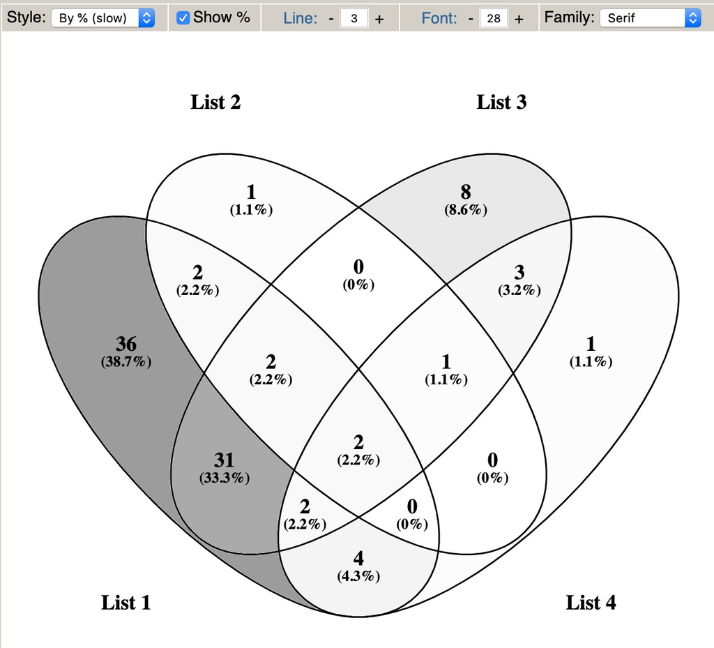

出自http://bioinfogp.cnb.csic.es/tools/venny/

# 应用场景

展示重叠关系，例如多个分组之间共有的、特异的差异表达基因。

适用于2、3或4个list的overlap，超过4个用upsetR更合适。

# 环境设置

安装包

```r
devtools::install_github("gaospecial/ggVennDiagram")
install.packages("export")
```

加载包

```r
library(stringr)
library(ggplot2)
library(ggVennDiagram)
library(export)

Sys.setenv(LANGUAGE = "en") #显示英文报错信息
options(stringsAsFactors = FALSE) #禁止chr转成factor
```

自定义函数

```r
# 读取文件并筛选差异表达基因，保留统计数值
read_cut <- function(file){
  df <- read.table(file, header = T)
  DEG <- df[df$FDR <= adjcutoff, ]
}

# 读取文件并筛选差异表达基因，只保留基因名
read_cut_ID <- function(file){
  df <- read.table(file, header = T)
  DEG <- df[df$FDR <= adjcutoff, ]$id
}

# 读取文件并筛选差异表达基因，把上调和下调分开，只保留基因名
read_cut_updown <- function(file){
  df <- read.table(file, header = T)
  DEG <- df[df$FDR <= adjcutoff, ]
  return(list(up = DEG[DEG$log2FC > 0,]$id,
              down = DEG[DEG$log2FC < 0,]$id))
}
```

# 输入文件

SKCM_*_test_result.*.txt，差异表达结果，可以包含全部基因，这里用FDR筛选显著差异基因。

> 怎样获得差异表达结果？
- 用[FigureYa59Plus_GEO2DEG](https://www.yuque.com/figureya/figureyaplus/figureya59p)获得芯片的差异表达分析结果文件`easy_input_limma.csv`
- 用FigureYa118MulticlassDESeq2、FigureYa119Multiclasslimma和FigureYa120MulticlassedgeR获得RNA-seq的差异表达分析结果。

这里就以FigureYa118MulticlassDESeq2和FigureYa120MulticlassedgeR的输出文件作为输入，画出venn图展示不同对比的重叠情况。

## 文件信息的整理

可参考`easy_input_info.txt`文件的格式，自己在Excel里写这个文件，至少要有第一列文件名和最后一列condition。

```r
# 读取输入文件
fnames <- Sys.glob("SKCM*.txt")

# 整理文件信息
finfo <- data.frame(file = fnames,
                 group = str_split_fixed(fnames, "\\.",3)[,2],
                 method = str_split_fixed(fnames, "_",3)[,2])
finfo$condition <- paste(finfo$group, finfo$method, sep = "_")
head(finfo)
```

```
##                                             file              group method
## 1 SKCM_deseq2_test_result.MITF-low_vs_Others.txt MITF-low_vs_Others deseq2
## 2   SKCM_deseq2_test_result.immune_vs_Others.txt   immune_vs_Others deseq2
## 3  SKCM_deseq2_test_result.keratin_vs_Others.txt  keratin_vs_Others deseq2
## 4  SKCM_edgeR_test_result.MITF-low_vs_Others.txt MITF-low_vs_Others  edgeR
## 5    SKCM_edgeR_test_result.immune_vs_Others.txt   immune_vs_Others  edgeR
## 6   SKCM_edgeR_test_result.keratin_vs_Others.txt  keratin_vs_Others  edgeR
##                   condition
## 1 MITF-low_vs_Others_deseq2
## 2   immune_vs_Others_deseq2
## 3  keratin_vs_Others_deseq2
## 4  MITF-low_vs_Others_edgeR
## 5    immune_vs_Others_edgeR
## 6   keratin_vs_Others_edgeR
```

```r
# 输出到文件
write.table(finfo, "easy_input_info.txt", row.names = F,quote = F, sep = "\t")
```

## 差异表达基因筛选

```r
# 读入文件信息
finfo <- read.table("easy_input_info.txt", header = T)

# 读入差异表达分析的结果，筛选显著差异基因
adjcutoff <- 0.05 #根据自己的数据修改阈值

# 读取文件并筛选差异表达基因
fdataset <- lapply(fnames, read_cut)
names(fdataset) <- finfo$condition

# 输出到Excel文件，每种对比结果占一个sheet，稍微修改一下格式就可以作为文章的Supplementary File了
openxlsx::write.xlsx(fdataset, file = paste0("DEG_adj", adjcutoff, ".xlsx"), row.names = F)
```

```
## Note: zip::zip() is deprecated, please use zip::zipr() instead
```

# 开始画图

## 两个圈

对比两个文件

以SKCM_deseq2_test_result.immune_vs_Others.txt和SKCM_edgeR_test_result.immune_vs_Others.txt为例，展示在两种方法中都被筛到的差异基因。

```r
# 读取带有immune_vs_Others的文件，筛选差异基因
list_ID <- lapply(finfo[finfo$group == "immune_vs_Others",]$file, read_cut_ID)
names(list_ID) <- finfo[finfo$group == "immune_vs_Others",]$method

# 画venn图
p <- ggVennDiagram(list_ID, label_alpha=0) +
  scale_fill_gradient(low="white", high = "lightblue")
```

```
## which will replace the existing scale.
```

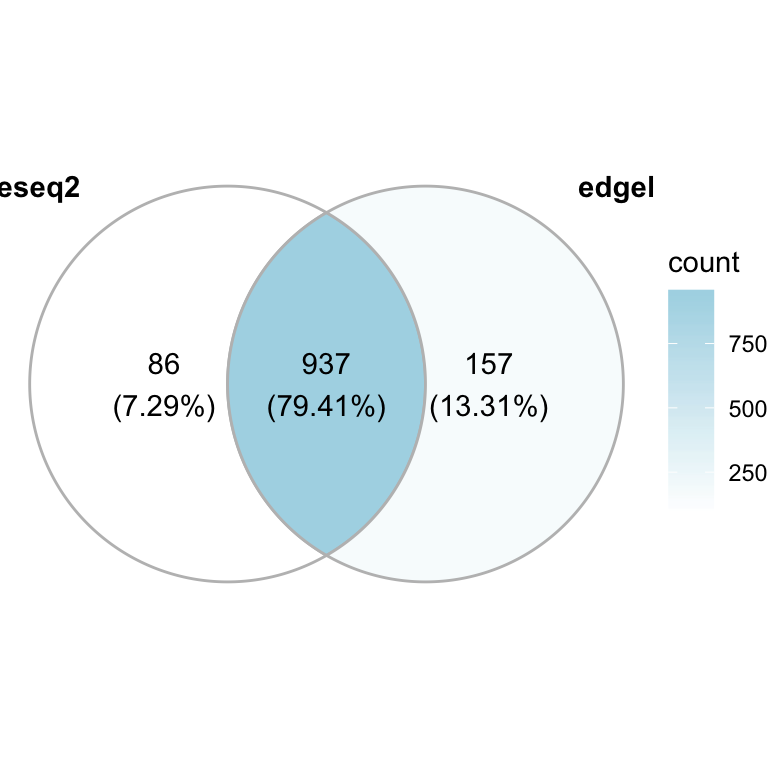

```r
p
```

```r
# 保存成pdf文件
ggsave("venn_2.pdf", width = 4, height = 4)
# 保存到ppt里
graph2ppt(p, file="venn_2.pptx",width = 4,height = 4)
```

```
## Exported graph as venn_2.pptx
```

```r
# 以上两种文件都是矢量图，可以在illustrator或ppt里打开修改文字和图形。

# 把各区域的基因输出到文件
openxlsx::write.xlsx(get_region_items(list_ID), "venn_2.xlsx")
```

## 四个圈

对比四个文件

以SKCM_deseq2_test_result.immune_vs_Others.txt和SKCM_edgeR_test_result.immune_vs_Others.txt为例，把上调和下调拆开，展示在两种方法中都被筛到的差异基因。

```r
file1 <- "SKCM_deseq2_test_result.immune_vs_Others.txt"
file2 <- "SKCM_edgeR_test_result.immune_vs_Others.txt"
list_ID <- list(deseq2_up = read_cut_updown(file1)$up,
                deseq2_down = read_cut_updown(file1)$down,
                edgeR_up = read_cut_updown(file2)$up,
                edgeR_up = read_cut_updown(file2)$down
)

# 画venn图
p <- ggVennDiagram(list_ID, label_alpha=0) +
  scale_fill_gradient(low="white", high = "lightblue")
```

```
## which will replace the existing scale.
```

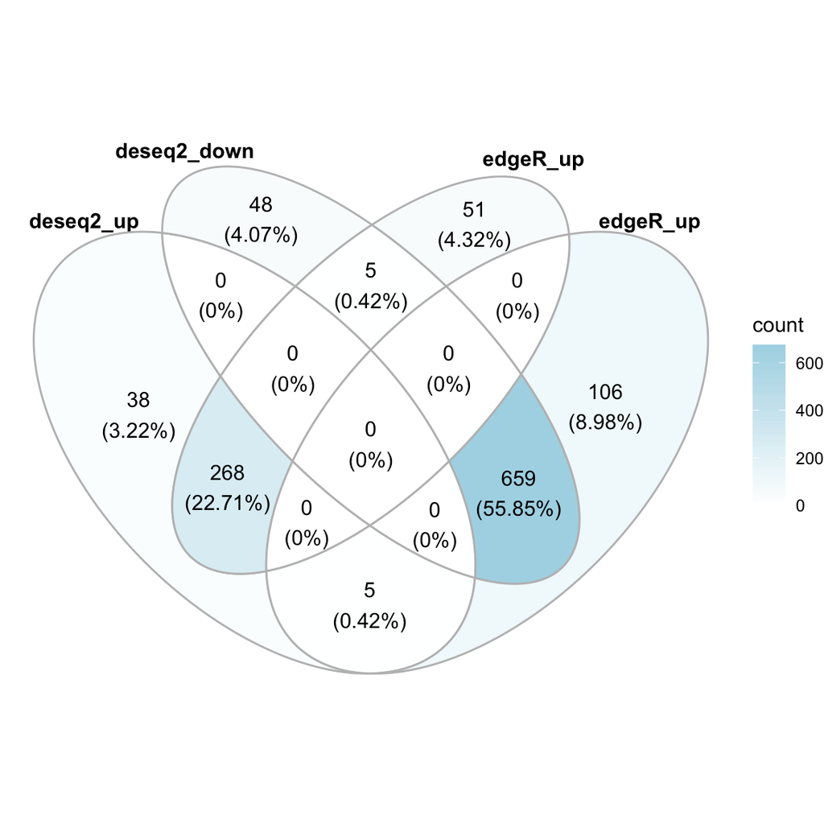

```r
p
```

```r
# 保存成pdf文件
ggsave("venn_4.pdf", width = 6, height = 6)

# 保存到ppt里
graph2ppt(p, file="venn_4.pptx",width = 6,height = 6)
```

```
## Exported graph as venn_4.pptx
```

```r
# 把各区域的基因输出到文件
openxlsx::write.xlsx(get_region_items(list_ID), "venn_4.xlsx")
```

## 三个圈

对比三个文件

以DESeq2获得的三种差异表达基因为例，展示其overlap

```r
# 读取带有deseq2的文件，筛选差异基因
list_ID <- lapply(finfo[finfo$method == "deseq2", ]$file, read_cut_ID)
names(list_ID) <- str_remove(finfo[finfo$method == "deseq2",]$group, "_vs_Others")

# 画venn图，这次换个配色
p <- ggVennDiagram(list_ID, label_alpha=0) +
  scale_fill_gradient(low="yellow", high = "brown")
```

```
## which will replace the existing scale.
```

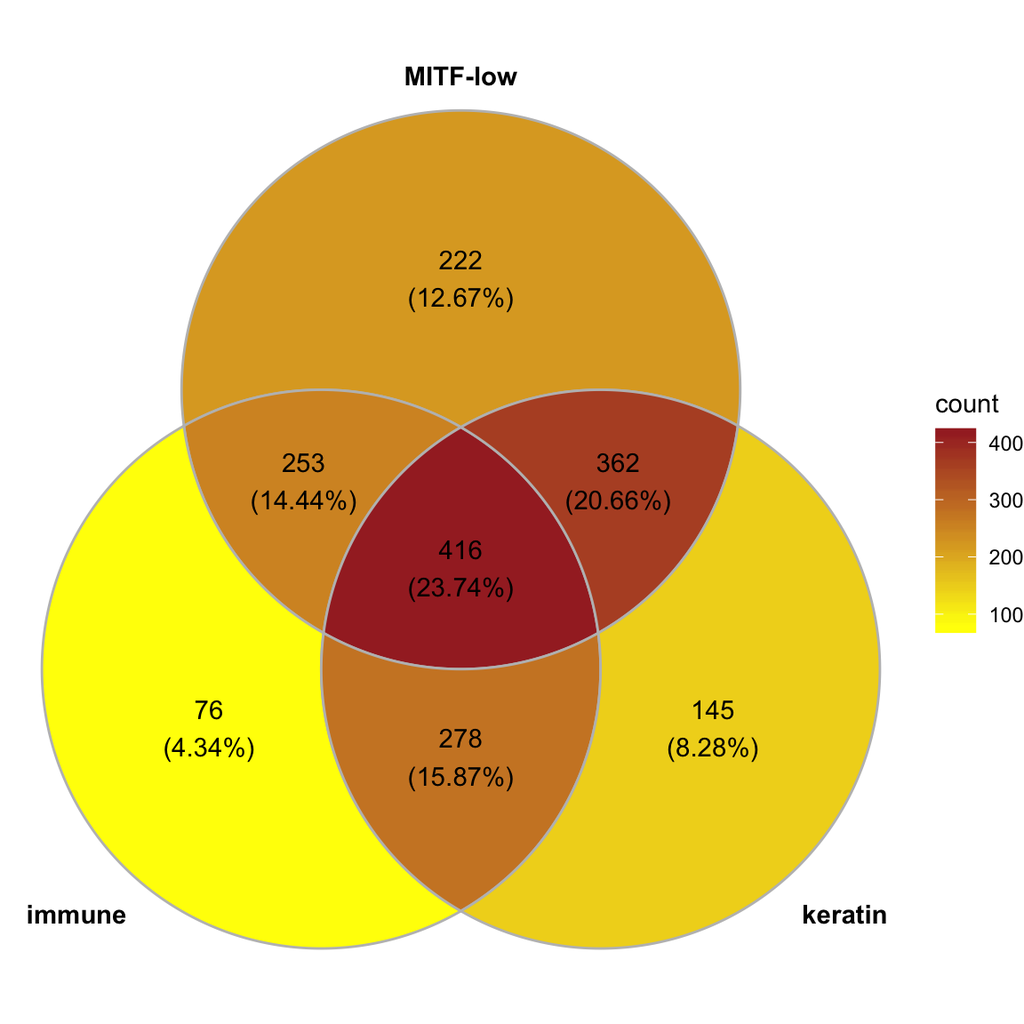

```r
p
```

```r
# 保存成pdf文件
ggsave(paste0("venn_3.pdf"), width = 6, height = 6)

# 保存到ppt里
graph2ppt(p, file="venn_3.pptx",width = 6,height = 6)
```

```
## Exported graph as venn_3.pptx
```

```r
# 把各区域的基因输出到文件
openxlsx::write.xlsx(get_region_items(list_ID), "venn_3.xlsx")
```